# Global Youth Literacy Trend 2018 to 2021

Author

Magaji Timya

📘 **Introduction**

This report presents an analysis of global youth literacy trends using selected indicators from the World Bank World Development Indicators dataset. The focus is on literacy rates among young people aged 15 to 24 across countries and over time. The objective is to explore overall trends, compare country performance, examine the relationship between male and female literacy, and visualize the geographical distribution of literacy rates.

The analysis combines time series, comparative ranking, correlation, and spatial mapping techniques to provide a well rounded understanding of global literacy patterns.

🗂️ **Data Source**

The dataset was obtained from the World Bank World Development Indicators database. The specific indicator used captures youth literacy rates for the population aged 15 to 24 years. The data covers multiple countries and years, although the number of reporting countries varies by year.

🛠️ **Data Preparation**

Before visualization, the dataset was cleaned and transformed to improve consistency and reliability.

The preparation steps included:

Selecting the relevant fields: Country, Year, LiteracyRate, and Sex. Removing missing or incomplete records. Converting year and literacy values into numeric format. Reshaping male and female literacy values where necessary for comparative analysis. Merging the literacy dataset with world map boundaries for spatial visualization.

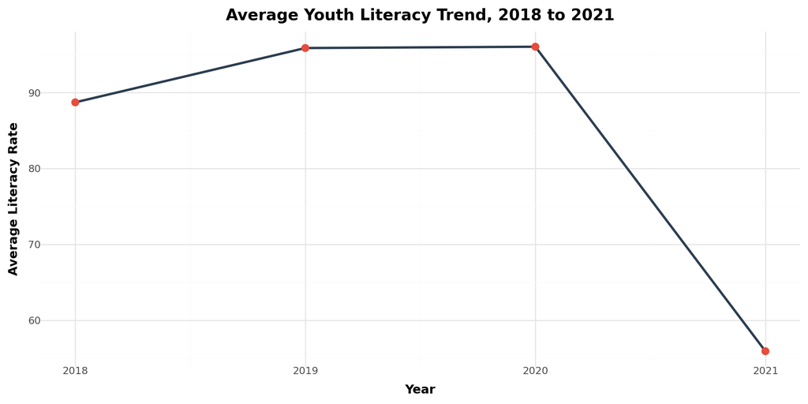

```python
(
    ggplot(trend, aes(x="Year", y="LiteracyRate"))
    + geom_line(color="#2C3E50", size=1.2)
    + geom_point(color="#E74C3C", size=3)
    + labs(
        title="Average Youth Literacy Trend, 2018 to 2021",
        x="Year",
        y="Average Literacy Rate"
    )
    + theme_minimal()
    + theme(
        figure_size=(10, 5),
        plot_title=element_text(size=14, weight="bold", ha="center"),
        axis_title=element_text(size=11, weight="bold"),
        axis_text=element_text(size=9)
    )
)
```

📈 **Visualisation 1. Time Series Chart**

The time series chart tracks average youth literacy rates across the selected years. This visual helps reveal whether global literacy among youth is improving, stable, or declining over time.

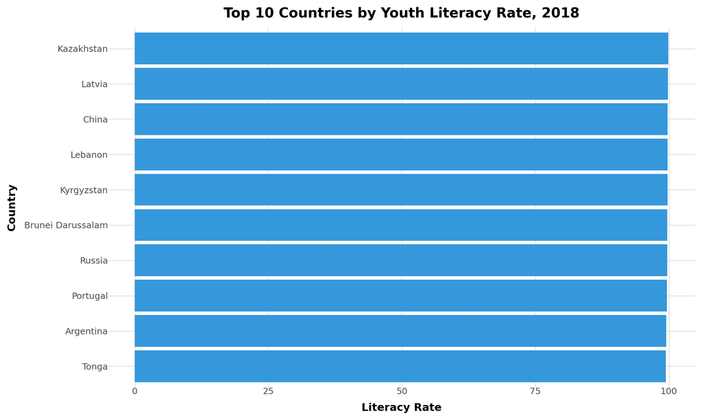

```python
(
    ggplot(bar_data, aes(x="reorder(Country, LiteracyRate)", y="LiteracyRate"))
    + geom_col(fill="#3498DB")
    + coord_flip()
    + labs(
        title=f"Top 10 Countries by Youth Literacy Rate, {best_year}",
        x="Country",
        y="Literacy Rate"
    )
    + theme_minimal()
    + theme(
        figure_size=(10, 6),
        plot_title=element_text(size=14, weight="bold", ha="center"),
        axis_title=element_text(size=11, weight="bold"),
        axis_text=element_text(size=9)
    )
)
```

📊 **Visualisation 2. Bar Chart. Country Ranking for 2018**

The bar chart ranks countries by youth literacy rate for the year 2018.

📌 **Note on Data Coverage**

A review of country availability across years shows that 2018 contains the highest number of valid country records, while later years, especially 2021, contain significantly fewer observations.

For this reason, 2018 is used for comparative country ranking and the world map, while 2021 is reserved only for analyses where sufficient data exists.

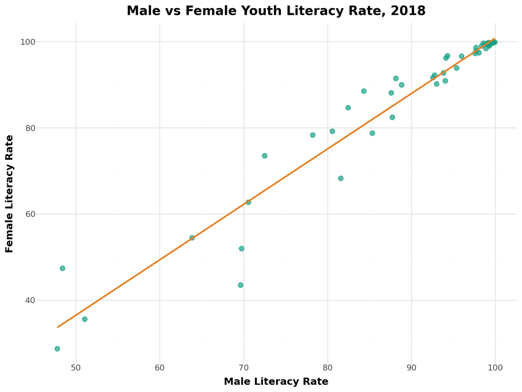

```python
(
    ggplot(scatter_data, aes(x="MaleRate", y="FemaleRate"))
    + geom_point(color="#16A085", size=2.5, alpha=0.7)
    + geom_smooth(method="lm", color="#E67E22", se=False)
    + labs(
        title=f"Male vs Female Youth Literacy Rate, {best_year}",
        x="Male Literacy Rate",
        y="Female Literacy Rate"
    )
    + theme_minimal()
    + theme(
        figure_size=(8, 6),
        plot_title=element_text(size=14, weight="bold", ha="center"),
        axis_title=element_text(size=11, weight="bold"),
        axis_text=element_text(size=9)
    )
)
```

🔍 **Visualisation 3. Scatterplot with Regression Line**

The scatterplot compares male and female youth literacy rates across countries.

The regression line indicates a strong positive relationship, showing that countries with high male literacy rates also tend to report high female literacy rates. This suggests that literacy outcomes for both genders often move together, although a few countries may still display gender gaps.

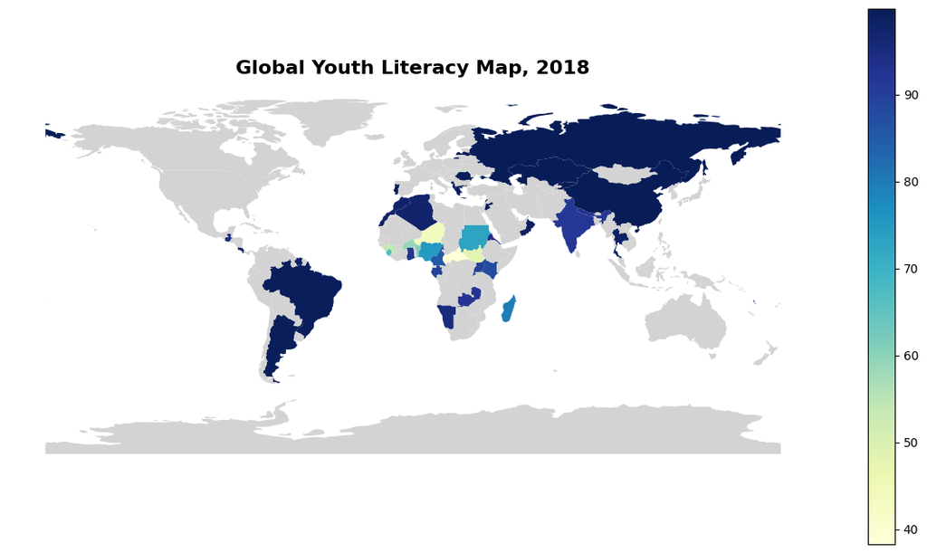

```python
ax = world_map.plot(
    column="LiteracyRate",
    cmap="YlGnBu",
    legend=True,
    figsize=(15, 8),
    missing_kwds={"color": "lightgrey"}
)
ax.set_title(f"Global Youth Literacy Map, {best_year}", fontsize=16, fontweight="bold")
ax.set_axis_off()
```

🌍 **Visualisation 4. World Map. Global Literacy Distribution for 2018**

The world map visualizes the spatial distribution of youth literacy rates across countries.

💡 **Key Findings**